# R for Beginners - R Code File -2

This R code book has been written by [Rohit Dhankar](https://github.com/RohitDhankar) . GitHub - https://github.com/RohitDhankar

This is the 2nd in series of R Code Files.

Refer GitHub Repository , for all Data Files –> https://github.com/RohitDhankar/R-Beginners-Online-Virtual-Learning-Session

Its a good practice from time to time to keep a track of our current Working Directory and list out all the Objects in our R ENVIRONMENT - specially so when we are committing changes to a Git Remote.

# VECTOR Operations

```r
ls(Proj_1)
```

```
‘Proj_1’ converted to character stringError in as.environment(pos) : no item called "Proj_1" on the search list
```

We could remove any object with command - rm(“Object Name”)

We can also use print() , to view any objects stored value.

```r
# Code Section -1
a1 <- "FINANCE"
b1 <- "MARKETING"
c1 <- "SALES"
d1 <- 3.1416
char_vector <- c("x","d","c","f")
print(a1)
```

```
[1] "FINANCE"
```

```r
#
print(char_vector)
```

```
[1] "x" "d" "c" "f"
```

Going further with VECTORS .

We combine two or more vectors to get another vector .

```r
seq_2<- 50:55
seq_2
```

```
[1] 50 51 52 53 54 55
```

Some basic Maths and Stats with VECTORS.

```r
typeof(nmv_vect)
```

```
[1] "double"
```

```r
col_names_4 <- paste( col_names_2,c("M","N","P"), sep="")
col_names_4
```

```
[1] "X1M" "Y2N" "Z3P"
```

Check out the LENGTH of a VECTOR with length()

```r
length(num_vector1 * num_vector3)
```

```
[1] 10
```

```r
nv %*% nv1 # Inner Product of same Length Vectors
```

```
     [,1]
[1,]  130
```

Operate upon a ELEMENT of the Vector.

```r
log(22)
```

```
[1] 3.091042
```

Converting a CHAR Vector into a NUMERIC Vector .

```r
dim(nm_v)
```

Wiki reference – Percentile Rank - “https://en.wikipedia.org/wiki/Percentile_rank” #

# Intro to ANOVA and BOXPLOTS

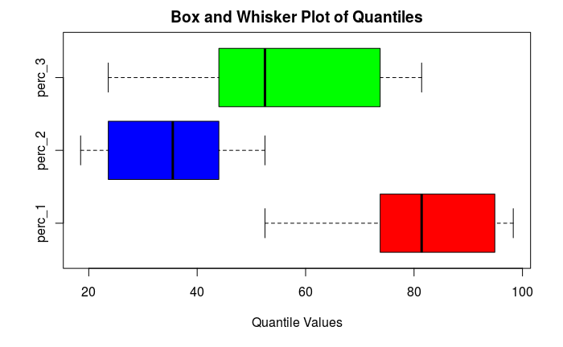

# rainbow() for Coloring Boxplots -

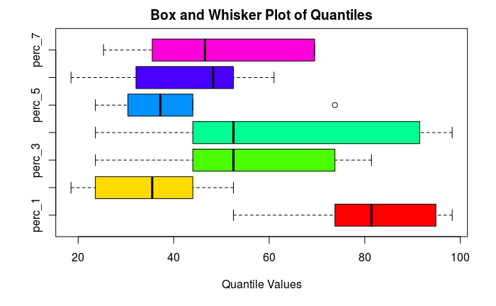

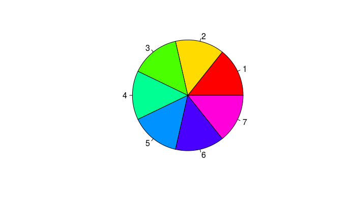

# MATRICE Operations - TRANSPOSE of a MATRIX

Coming back to MATRICES lets further look at some MATRIX Operations :-

```r
t(m2)
```

```
     [,1] [,2] [,3] [,4]
[1,]   10   11   12   13
[2,]   14   15   16   17
[3,]   18   19   20   21
[4,]   22   23   24   25
```

# The Semicolon Notation - RANGE or SEQUENCE

```r
typeof(c_seq)
```

```
[1] "double"
```

# The CBIND and RBIND Functions

We can COLUMN Bind and ROW Bind more than one data structures as seen below -

```r
m3 <- rbind(m1,m2)
```

```
Error in rbind(m1, m2) :
  number of columns of matrices must match (see arg 2)
```

# ROW BIND - Data Frames

| X. | Product.Name | Prod.ID | Date.of.Invoice | Date.of.Shipping | Cost.Price | Quantity | Sales.Price | Shipping.Index | Shipping.Type | Category |
| --- | --- | --- | --- | --- | --- | --- | --- | --- | --- | --- |
| 1 | OFF-LA-10002782 | MX-2014-143658 | 01-01-2013 | 02-01-2013 | 13.080 | 3 | 39.240 | 1 | PRIORITY | Office Supplies |
| 2 | FUR-FU-10004015 | MX-2012-155047 | 01-01-2013 | 02-01-2013 | 252.160 | 8 | 2017.280 | 2 | PRIORITY | Furniture |
| 3 | FUR-BO-10002352 | MX-2012-155047 | 01-01-2013 | 02-01-2013 | 193.280 | 2 | 386.560 | 3 | PRIORITY | Furniture |
| 4 | OFF-BI-10004428 | MX-2012-155047 | 01-01-2013 | 02-01-2013 | 35.440 | 4 | 141.760 | 4 | PRIORITY | Office Supplies |
| 5 | OFF-AR-10004594 | MX-2012-155047 | 01-01-2013 | 02-01-2013 | 71.600 | 2 | 143.200 | 5 | PRIORITY | Office Supplies |
| 6 | OFF-EN-10001375 | MX-2012-155047 | 01-01-2013 | 02-01-2013 | 56.120 | 2 | 112.240 | 6 | PRIORITY | Office Supplies |
| 7 | OFF-EN-10001375 | MX-2013-134096 | 01-01-2013 | 02-01-2013 | 56.120 | 2 | 112.240 | 7 | STANDARD | Office Supplies |
| 8 | TEC-MA-10004956 | MX-2013-134096 | 01-01-2013 | 02-01-2013 | 344.640 | 3 | 1033.920 | 8 | STANDARD | Technology |
| 9 | OFF-SU-10003474 | MX-2013-134096 | 01-01-2013 | 02-01-2013 | 97.360 | 4 | 389.440 | 9 | STANDARD | Office Supplies |
| 10 | TEC-AC-10001830 | MX-2013-134096 | 01-01-2013 | 02-01-2013 | 341.520 | 2 | 683.040 | 10 | STANDARD | Technology |

[output cut: 15 more lines]

| X. | Product.Name | Prod.ID | Date.of.Invoice | Date.of.Shipping | Cost.Price | Quantity | Sales.Price | Shipping.Index | Shipping.Type | Category |
| --- | --- | --- | --- | --- | --- | --- | --- | --- | --- | --- |
| 1 | TEC-AC-10001830 | MX-2013-134096 | 05-01-2013 | 06-01-2013 | 341.520 | 2 | 683.040 | 10 | STANDARD | Technology |
| 2 | FUR-FU-10004015 | MX-2012-155047 | 03-01-2013 | 03-01-2013 | 252.160 | 8 | 2017.280 | 2 | PRIORITY | Furniture |
| 3 | FUR-BO-10002352 | MX-2012-155047 | 03-01-2013 | 03-01-2013 | 193.280 | 2 | 386.560 | 3 | PRIORITY | Furniture |
| 4 | OFF-BI-10004428 | MX-2012-155047 | 03-01-2013 | 03-01-2013 | 35.440 | 4 | 141.760 | 4 | PRIORITY | Office Supplies |
| 5 | OFF-AR-10004594 | MX-2012-155047 | 03-01-2013 | 03-01-2013 | 71.600 | 2 | 143.200 | 5 | PRIORITY | Office Supplies |
| 6 | OFF-EN-10001375 | MX-2012-155047 | 03-01-2013 | 03-01-2013 | 56.120 | 2 | 112.240 | 6 | PRIORITY | Office Supplies |
| 7 | OFF-EN-10001375 | MX-2013-134096 | 03-01-2013 | 04-01-2013 | 56.120 | 2 | 112.240 | 7 | STANDARD | Office Supplies |
| 8 | OFF-AR-10003914 | MX-2014-135706 | 03-01-2013 | 04-01-2013 | 132.640 | 4 | 530.560 | 15 | STANDARD | Office Supplies |
| 9 | OFF-FA-10000038 | MX-2014-135706 | 03-01-2013 | 04-01-2013 | 12.940 | 1 | 12.940 | 16 | STANDARD | Office Supplies |
| 10 | OFF-EN-10000761 | US-2013-126655 | 03-01-2013 | 04-01-2013 | 18.840 | 2 | 37.280 | 17 | STANDARD | Office Supplies |

[output cut: 40 more lines]

# COLUMN BIND- Data Frame

```r
summary(df_1)
```

```
       X.              Product.Name           Prod.ID    Date.of.Invoice   Date.of.Shipping   Cost.Price         Quantity    Sales.Price
 Min.   : 1   OFF-EN-10001375: 2    MX-2012-155047:5   01-01-2013:13     02-01-2013:15      Min.   :  8.784   Min.   :1.0   Min.   :  12.94
 1st Qu.: 7   FUR-BO-10002352: 1    MX-2013-134096:5   02-01-2013:12     03-01-2013: 8      1st Qu.: 27.000   1st Qu.:2.0   1st Qu.:  62.28
 Median :13   FUR-CH-10002132: 1    US-2013-126655:4                     04-01-2013: 2      Median : 71.600   Median :3.0   Median : 181.58
 Mean   :13   FUR-CH-10002846: 1    MX-2013-156335:2                                        Mean   :122.231   Mean   :3.6   Mean   : 555.18
 3rd Qu.:19   FUR-FU-10003066: 1    MX-2013-163139:2                                        3rd Qu.:207.000   3rd Qu.:4.0   3rd Qu.: 842.56
 Max.   :25   FUR-FU-10004015: 1    MX-2014-135706:2                                        Max.   :344.640   Max.   :9.0   Max.   :2157.56
              (Other)        :18    (Other)       :5
 Shipping.Index  Shipping.Type            Category
 Min.   : 1     PRIORITY:12    Furniture      : 5
 1st Qu.: 7     STANDARD:13    Office Supplies:17
 Median :13                    Technology     : 3
 Mean   :13
 3rd Qu.:19
 Max.   :25
```

```r
summary(df_2)
```

```
       X.                 Product.Name           Prod.ID     Date.of.Invoice   Date.of.Shipping   Cost.Price         Quantity
 Min.   : 1.00   OFF-EN-10001375: 8    MX-2012-155047: 5   03-01-2013:20     03-01-2013: 8      Min.   :  8.784   Min.   :1.00
 1st Qu.:13.25   OFF-SU-10003474: 6    MX-2013-134096:30   04-01-2013:23     04-01-2013:14      1st Qu.: 24.430   1st Qu.:2.00
 Median :25.50   TEC-AC-10001830: 6    MX-2013-156335: 2   05-01-2013: 7     05-01-2013:21      Median : 84.480   Median :3.00
 Mean   :25.50   TEC-MA-10004956: 6    MX-2013-167759: 2                     06-01-2013: 7      Mean   :145.243   Mean   :3.02
 3rd Qu.:37.75   OFF-BI-10002075: 5    MX-2014-135706: 2                                        3rd Qu.:308.280   3rd Qu.:3.75
 Max.   :50.00   FUR-CH-10002132: 2    MX-2014-143658: 1                                        Max.   :344.640   Max.   :8.00
                 (Other)        :17    US-2013-126655: 8
  Sales.Price      Shipping.Index   Shipping.Type            Category
 Min.   :  12.94   Min.   : 1.00   PRIORITY:10    Furniture      : 6
 1st Qu.:  66.70   1st Qu.: 7.25   STANDARD:40    Office Supplies:32
 Median : 264.88   Median : 9.50                  Technology     :12
 Mean   : 478.04   Mean   :10.64
 3rd Qu.: 683.04   3rd Qu.:12.00
 Max.   :2157.56   Max.   :21.00
```

```r
df_3_C <- cbind(df_1,df_2)
df_3_C
```

| X. | Product.Name | Prod.ID | Date.of.Invoice | Date.of.Shipping | Cost.Price | Quantity | Sales.Price | Shipping.Index | Shipping.Type | Category | X. | Product.Name | Prod.ID | Date.of.Invoice | Date.of.Shipping | Cost.Price | Quantity | Sales.Price | Shipping.Index | Shipping.Type | Category |
| --- | --- | --- | --- | --- | --- | --- | --- | --- | --- | --- | --- | --- | --- | --- | --- | --- | --- | --- | --- | --- | --- |
| 1 | OFF-LA-10002782 | MX-2014-143658 | 01-01-2013 | 02-01-2013 | 13.080 | 3 | 39.240 | 1 | PRIORITY | Office Supplies | 1 | TEC-AC-10001830 | MX-2013-134096 | 05-01-2013 | 06-01-2013 | 341.520 | 2 | 683.040 | 10 | STANDARD | Technology |
| 2 | FUR-FU-10004015 | MX-2012-155047 | 01-01-2013 | 02-01-2013 | 252.160 | 8 | 2017.280 | 2 | PRIORITY | Furniture | 2 | FUR-FU-10004015 | MX-2012-155047 | 03-01-2013 | 03-01-2013 | 252.160 | 8 | 2017.280 | 2 | PRIORITY | Furniture |
| 3 | FUR-BO-10002352 | MX-2012-155047 | 01-01-2013 | 02-01-2013 | 193.280 | 2 | 386.560 | 3 | PRIORITY | Furniture | 3 | FUR-BO-10002352 | MX-2012-155047 | 03-01-2013 | 03-01-2013 | 193.280 | 2 | 386.560 | 3 | PRIORITY | Furniture |
| 4 | OFF-BI-10004428 | MX-2012-155047 | 01-01-2013 | 02-01-2013 | 35.440 | 4 | 141.760 | 4 | PRIORITY | Office Supplies | 4 | OFF-BI-10004428 | MX-2012-155047 | 03-01-2013 | 03-01-2013 | 35.440 | 4 | 141.760 | 4 | PRIORITY | Office Supplies |
| 5 | OFF-AR-10004594 | MX-2012-155047 | 01-01-2013 | 02-01-2013 | 71.600 | 2 | 143.200 | 5 | PRIORITY | Office Supplies | 5 | OFF-AR-10004594 | MX-2012-155047 | 03-01-2013 | 03-01-2013 | 71.600 | 2 | 143.200 | 5 | PRIORITY | Office Supplies |
| 6 | OFF-EN-10001375 | MX-2012-155047 | 01-01-2013 | 02-01-2013 | 56.120 | 2 | 112.240 | 6 | PRIORITY | Office Supplies | 6 | OFF-EN-10001375 | MX-2012-155047 | 03-01-2013 | 03-01-2013 | 56.120 | 2 | 112.240 | 6 | PRIORITY | Office Supplies |
| 7 | OFF-EN-10001375 | MX-2013-134096 | 01-01-2013 | 02-01-2013 | 56.120 | 2 | 112.240 | 7 | STANDARD | Office Supplies | 7 | OFF-EN-10001375 | MX-2013-134096 | 03-01-2013 | 04-01-2013 | 56.120 | 2 | 112.240 | 7 | STANDARD | Office Supplies |
| 8 | TEC-MA-10004956 | MX-2013-134096 | 01-01-2013 | 02-01-2013 | 344.640 | 3 | 1033.920 | 8 | STANDARD | Technology | 8 | OFF-AR-10003914 | MX-2014-135706 | 03-01-2013 | 04-01-2013 | 132.640 | 4 | 530.560 | 15 | STANDARD | Office Supplies |
| 9 | OFF-SU-10003474 | MX-2013-134096 | 01-01-2013 | 02-01-2013 | 97.360 | 4 | 389.440 | 9 | STANDARD | Office Supplies | 9 | OFF-FA-10000038 | MX-2014-135706 | 03-01-2013 | 04-01-2013 | 12.940 | 1 | 12.940 | 16 | STANDARD | Office Supplies |
| 10 | TEC-AC-10001830 | MX-2013-134096 | 01-01-2013 | 02-01-2013 | 341.520 | 2 | 683.040 | 10 | STANDARD | Technology | 10 | OFF-EN-10000761 | US-2013-126655 | 03-01-2013 | 04-01-2013 | 18.840 | 2 | 37.280 | 17 | STANDARD | Office Supplies |

[output cut: 40 more lines]

```r
summary(df_3_C)
```

```
       X.              Product.Name           Prod.ID     Date.of.Invoice   Date.of.Shipping   Cost.Price         Quantity    Sales.Price
 Min.   : 1   OFF-EN-10001375: 4    MX-2012-155047:10   01-01-2013:26     02-01-2013:30      Min.   :  8.784   Min.   :1.0   Min.   :  12.94
 1st Qu.: 7   FUR-BO-10002352: 2    MX-2013-134096:10   02-01-2013:24     03-01-2013:16      1st Qu.: 27.000   1st Qu.:2.0   1st Qu.:  62.28
 Median :13   FUR-CH-10002132: 2    US-2013-126655: 8                     04-01-2013: 4      Median : 71.600   Median :3.0   Median : 181.58
 Mean   :13   FUR-CH-10002846: 2    MX-2013-156335: 4                                        Mean   :122.231   Mean   :3.6   Mean   : 555.18
 3rd Qu.:19   FUR-FU-10003066: 2    MX-2013-163139: 4                                        3rd Qu.:207.000   3rd Qu.:4.0   3rd Qu.: 842.56
 Max.   :25   FUR-FU-10004015: 2    MX-2014-135706: 4                                        Max.   :344.640   Max.   :9.0   Max.   :2157.56
              (Other)        :36    (Other)       :10
 Shipping.Index  Shipping.Type            Category        X.                 Product.Name           Prod.ID     Date.of.Invoice
 Min.   : 1     PRIORITY:24    Furniture      :10   Min.   : 1.00   OFF-EN-10001375: 8    MX-2012-155047: 5   03-01-2013:20
 1st Qu.: 7     STANDARD:26    Office Supplies:34   1st Qu.:13.25   OFF-SU-10003474: 6    MX-2013-134096:30   04-01-2013:23
 Median :13                    Technology     : 6   Median :25.50   TEC-AC-10001830: 6    MX-2013-156335: 2   05-01-2013: 7
 Mean   :13                                         Mean   :25.50   TEC-MA-10004956: 6    MX-2013-167759: 2
 3rd Qu.:19                                         3rd Qu.:37.75   OFF-BI-10002075: 5    MX-2014-135706: 2
 Max.   :25                                         Max.   :50.00   FUR-CH-10002132: 2    MX-2014-143658: 1
                                                                    (Other)        :17    US-2013-126655: 8
   Date.of.Shipping   Cost.Price         Quantity     Sales.Price      Shipping.Index   Shipping.Type            Category
 03-01-2013: 8      Min.   :  8.784   Min.   :1.00   Min.   :  12.94   Min.   : 1.00   PRIORITY:10    Furniture      : 6
 04-01-2013:14      1st Qu.: 24.430   1st Qu.:2.00   1st Qu.:  66.70   1st Qu.: 7.25   STANDARD:40    Office Supplies:32
 05-01-2013:21      Median : 84.480   Median :3.00   Median : 264.88   Median : 9.50                  Technology     :12
 06-01-2013: 7      Mean   :145.243   Mean   :3.02   Mean   : 478.04   Mean   :10.64
                    3rd Qu.:308.280   3rd Qu.:3.75   3rd Qu.: 683.04   3rd Qu.:12.00
                    Max.   :344.640   Max.   :8.00   Max.   :2157.56   Max.   :21.00
```

# ROW BIND - Data Frame

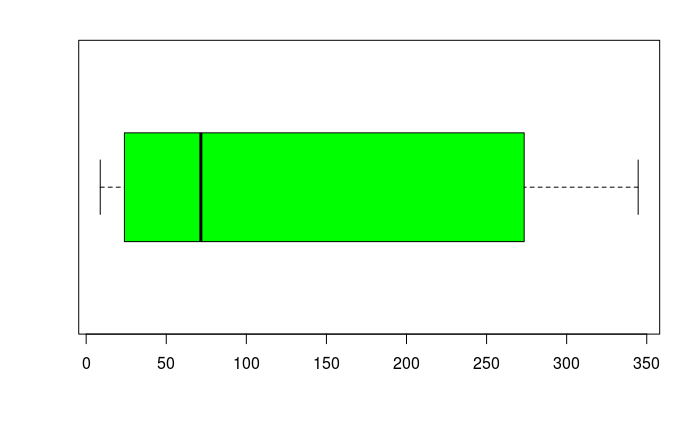

# describeBy— with Grouping variables

```r
describeBy(df_3_C,df_3_C$Date.of.Invoice)
```

```
 Descriptive statistics by group
group: 01-01-2013
   vars  n   mean     sd median trimmed    mad   min     max   range  skew kurtosis     se
1     1 26   7.00   3.82   7.00    7.00   4.45  1.00   13.00   12.00  0.00    -1.35   0.75
2     2 26  12.85   7.49  14.00   12.91  10.38  1.00   24.00   23.00 -0.06    -1.45   1.47
3     3 26   2.23   1.84   2.00    1.82   1.48  1.00    8.00    7.00  2.27     4.52   0.36
4     4 26   1.00   0.00   1.00    1.00   0.00  1.00    1.00    0.00   NaN      NaN   0.00
5     5 26   1.00   0.00   1.00    1.00   0.00  1.00    1.00    0.00   NaN      NaN   0.00
6     6 26 131.14 120.02  71.60  122.55  86.76 12.06  344.64  332.58  0.66    -1.14  23.54
7     7 26   3.23   1.61   3.00    2.91   1.48  2.00    8.00    6.00  1.86     3.10   0.32
8     8 26 461.53 559.95 143.20  358.77 158.67 36.18 2017.28 1981.10  1.60     1.80 109.82
9     9 26   7.00   3.82   7.00    7.00   4.45  1.00   13.00   12.00  0.00    -1.35   0.75
10   10 26   1.54   0.51   2.00    1.55   0.00  1.00    2.00    1.00 -0.15    -2.05   0.10
11   11 26   1.92   0.63   2.00    1.91   0.00  1.00    3.00    2.00  0.04    -0.59   0.12
12   12 26  19.50  13.31  19.50   19.50  18.53  1.00   38.00   37.00  0.00    -1.79   2.61
```

[output cut: 35 more lines]

# Built in DATA Sets

The default R environment - comes bundled with a number of packages and data sets.

A package called DATASETS - contains a number of inbuilt data sets as seen in sections below -

```r
# Code Section -20
library(help = "datasets")
#
# Seen below are the DataSets available within my installed version of R -
# yours may slightly differ :-
#
# AirPassengers           Monthly Airline Passenger Numbers 1949-1960
# BJsales                 Sales Data with Leading Indicator
# BOD                     Biochemical Oxygen Demand
# CO2                     Carbon Dioxide Uptake in Grass Plants
# ChickWeight             Weight versus age of chicks on different diets
# DNase                   Elisa assay of DNase
# EuStockMarkets          Daily Closing Prices of Major European Stock
#                         Indices, 1991-1998
# Formaldehyde            Determination of Formaldehyde
# HairEyeColor            Hair and Eye Color of Statistics Students
# Harman23.cor            Harman Example 2.3
# Harman74.cor            Harman Example 7.4
# Indometh                Pharmacokinetics of Indomethacin
# InsectSprays            Effectiveness of Insect Sprays
# JohnsonJohnson          Quarterly Earnings per Johnson & Johnson Share
# LakeHuron               Level of Lake Huron 1875-1972
# LifeCycleSavings        Intercountry Life-Cycle Savings Data
# Loblolly                Growth of Loblolly pine trees
# Nile                    Flow of the River Nile
# Orange                  Growth of Orange Trees
# OrchardSprays           Potency of Orchard Sprays
# PlantGrowth             Results from an Experiment on Plant Growth
# Puromycin               Reaction Velocity of an Enzymatic Reaction
# Theoph                  Pharmacokinetics of Theophylline
# Titanic                 Survival of passengers on the Titanic
# ToothGrowth             The Effect of Vitamin C on Tooth Growth in
#                         Guinea Pigs
# UCBAdmissions           Student Admissions at UC Berkeley
# UKDriverDeaths          Road Casualties in Great Britain 1969-84
# UKLungDeaths            Monthly Deaths from Lung Diseases in the UK
# UKgas                   UK Quarterly Gas Consumption
# USAccDeaths             Accidental Deaths in the US 1973-1978
# USArrests               Violent Crime Rates by US State
# USJudgeRatings          Lawyers' Ratings of State Judges in the US
#                         Superior Court
# USPersonalExpenditure   Personal Expenditure Data
# VADeaths                Death Rates in Virginia (1940)
# WWWusage                Internet Usage per Minute
# WorldPhones             The World's Telephones
# ability.cov             Ability and Intelligence Tests
# airmiles                Passenger Miles on Commercial US Airlines,
#                         1937-1960
# airquality              New York Air Quality Measurements
# anscombe                Anscombe's Quartet of 'Identical' Simple Linear
#                         Regressions
# attenu                  The Joyner-Boore Attenuation Data
# attitude                The Chatterjee-Price Attitude Data
# austres                 Quarterly Time Series of the Number of
#                         Australian Residents
# beavers                 Body Temperature Series of Two Beavers
# cars                    Speed and Stopping Distances of Cars
# chickwts                Chicken Weights by Feed Type
# co2                     Mauna Loa Atmospheric CO2 Concentration
# crimtab                 Student's 3000 Criminals Data
# datasets-package        The R Datasets Package
# discoveries             Yearly Numbers of Important Discoveries
# esoph                   Smoking, Alcohol and (O)esophageal Cancer
# euro                    Conversion Rates of Euro Currencies
# eurodist                Distances Between European Cities and Between
#                         US Cities
# faithful                Old Faithful Geyser Data
# freeny                  Freeny's Revenue Data
# infert                  Infertility after Spontaneous and Induced
#                         Abortion
# iris                    Edgar Anderson's Iris Data
# islands                 Areas of the World's Major Landmasses
# lh                      Luteinizing Hormone in Blood Samples
# longley                 Longley's Economic Regression Data
# lynx                    Annual Canadian Lynx trappings 1821-1934
# morley                  Michelson Speed of Light Data
# mtcars                  Motor Trend Car Road Tests
# nhtemp                  Average Yearly Temperatures in New Haven
# nottem                  Average Monthly Temperatures at Nottingham,
#                         1920-1939
# npk                     Classical N, P, K Factorial Experiment
# occupationalStatus      Occupational Status of Fathers and their Sons
# precip                  Annual Precipitation in US Cities
# presidents              Quarterly Approval Ratings of US Presidents
# pressure                Vapor Pressure of Mercury as a Function of
#                         Temperature
# quakes                  Locations of Earthquakes off Fiji
# randu                   Random Numbers from Congruential Generator
#                         RANDU
# rivers                  Lengths of Major North American Rivers
# rock                    Measurements on Petroleum Rock Samples
# sleep                   Student's Sleep Data
# stackloss               Brownlee's Stack Loss Plant Data
# state                   US State Facts and Figures
# sunspot.month           Monthly Sunspot Data, from 1749 to "Present"
# sunspot.year            Yearly Sunspot Data, 1700-1988
# sunspots                Monthly Sunspot Numbers, 1749-1983
# swiss                   Swiss Fertility and Socioeconomic Indicators
#                         (1888) Data
# treering                Yearly Treering Data, -6000-1979
# trees                   Girth, Height and Volume for Black Cherry Trees
# uspop                   Populations Recorded by the US Census
# volcano                 Topographic Information on Auckland's Maunga
#                         Whau Volcano
# warpbreaks              The Number of Breaks in Yarn during Weaving
# women                   Average Heights and Weights for American Women
#
```

# ATTACH and DETACH Datasets

To OPERATE upon an inbuilt DATASET we need to LOAD it into R .

In lay-man terms , we may equate this to our earlier - read.csv() , but

there are subtle differences.

The ATTACH will pull in a Data Set from the DataSet Package into our R Search Path.

```r
# Code Section -21
?attach()
# # Quoting below from inbuilt HELP -
# # The database is attached to the R search path. This means that the database is
# searched by R when evaluating a variable, so objects in the database can be accessed
# by simply giving their names.
?detach()
# # Quoting below from inbuilt HELP -
# # Detach a database, i.e., remove it from the search() path of available R objects.
# Usually this is either a data.frame which has been attached or a
# package which was attached by library.
# Another Function which will help automate is - zap()
# library(epicalc)
# ?zap()
# https://artax.karlin.mff.cuni.cz/r-help/library/epicalc/html/zap.html
```

```r
search()
```

```
 [1] ".GlobalEnv"        "tools:rstudio"     "package:stats"     "package:graphics"  "package:grDevices"
 [6] "package:utils"     "package:datasets"  "package:methods"   "Autoloads"         "package:base"
```

# DATA_FRAME COLUMNS - The DF Column Vector

```r
print(df_1[[2]]) # Will Print 2nd COLUMN of the DF
```

```
 [1] OFF-LA-10002782 FUR-FU-10004015 FUR-BO-10002352 OFF-BI-10004428 OFF-AR-10004594 OFF-EN-10001375 OFF-EN-10001375 TEC-MA-10004956
 [9] OFF-SU-10003474 TEC-AC-10001830 OFF-BI-10002075 OFF-FA-10002526 FUR-CH-10002846 OFF-EN-10004100 OFF-AR-10003914 OFF-FA-10000038
[17] OFF-EN-10000761 FUR-FU-10003066 OFF-EN-10000075 OFF-EN-10002226 FUR-CH-10002132 TEC-AC-10002749 OFF-SU-10000066 OFF-BI-10003934
[25] OFF-BI-10003932
24 Levels: FUR-BO-10002352 FUR-CH-10002132 FUR-CH-10002846 FUR-FU-10003066 FUR-FU-10004015 OFF-AR-10003914 ... TEC-MA-10004956
```

# DATA_FRAME - Row and Column Slices

| Product.Name | Date.of.Invoice | Cost.Price |
| --- | --- | --- |
| OFF-LA-10002782 | 01-01-2013 | 13.080 |
| FUR-FU-10004015 | 01-01-2013 | 252.160 |
| FUR-BO-10002352 | 01-01-2013 | 193.280 |
| OFF-BI-10004428 | 01-01-2013 | 35.440 |
| OFF-AR-10004594 | 01-01-2013 | 71.600 |
| OFF-EN-10001375 | 01-01-2013 | 56.120 |
| OFF-EN-10001375 | 01-01-2013 | 56.120 |
| TEC-MA-10004956 | 01-01-2013 | 344.640 |
| OFF-SU-10003474 | 01-01-2013 | 97.360 |
| TEC-AC-10001830 | 01-01-2013 | 341.520 |

[output cut: 15 more lines]

Lets create a New Directory - Files Folder from within R and house our basic introductory graphs there - we use - dir.create()

# Plots and Graphs - the Basics

Over the next couple of sections we shall preview the basics of Plots and Graphs.

If we were to execute the code from the following sections , in the Console- the Graphs would not appear inline but would appear within the PLOTS pane of R Studio or in certain cases as POP Up’s.

# HISTOGRAM an Introduction

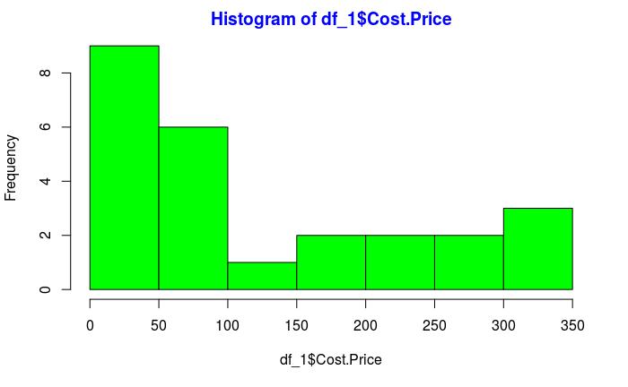

# par() Function - Multiple adjacent plots

par{graphics}

Next sections we look at some basic usage of the par() function , with it we can create a matrix of nrows X ncolumns - of various plots and graphs

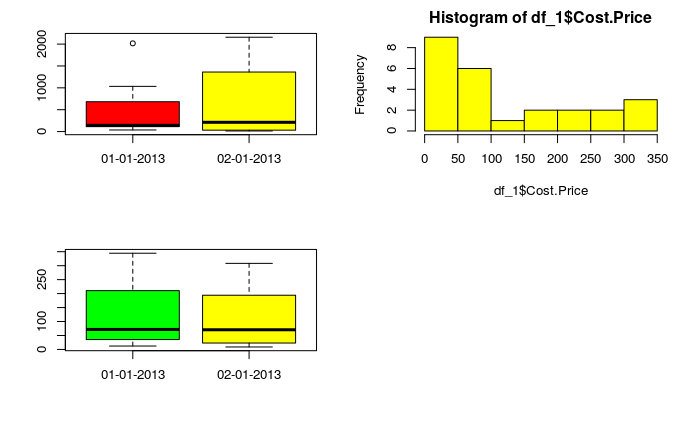

# LAYOUT of Plots - beyond the par()

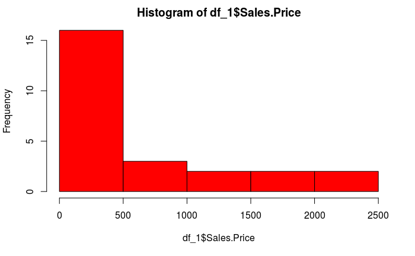

# SCATTER Plot - initial Intro

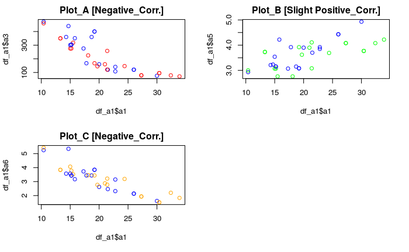

Plot_A - Var “a1” and “a3” seem to be Highly Correlated . As values of “a1” increase the values of “a3” decrease.

Plot_C - Var “a1” and “a6” seem to be Highly Correlated . As values of “a1” increase the values of “a6” decrease.